# Simulación de Modelos Probabilísticos

León Berdichevsky Acosta

16 de octubre de 2018

### Modelos gráficos

El objetivo de esta sección es la simulación de modelos, una manera conveniente de simular un modelo probabilístico es a partir del modelo gráfico asociado. Un modelo gráfico representa todas las cantidades involucradas en el modelo mediante nodos de una gráfica dirigida.

Los nodos en las gráficas se clasifican en 3 tipos:

- **Constantes** fijas por el diseño del estudio, siempre son nodos sin padres.
- **Estocásticos**: son variables a los que se les asigna una distribución.
- **Determinísticos**: son funciones lógicas de otros nodos.

El modelo representa el supuesto de que cada nodo $v$ depende únicamente de los nodos padres $padres(v)$ y es independiente del resto de los nodos.

Los supuestos de independencia condicional que representa la gráfica implican que la distribución conjunta de todas las $n$ cantidades del modelo $V=\{v_1,..., v_n\}$ tiene una factorización en términos de la distribución condicional $p(v_i|padres(v_i))$ de tal manera que:
$$p(V) = \prod_{i=1}^{n} p(v_i|padres(v_i))$$

Veamos como usar las gráficas para simular modelos probabilísticos. Los siguientes ejemplos están escritos con base en el libro [Data Analysis using Regression and Multilevel Hierarchical Models](http://www.stat.columbia.edu/~gelman/arm/) de Gelman y Hill.

### Simulación discreta predictiva

**Ejemplo:** La probabilidad de que un bebé sea niña o niño es 48.8% y 51.2%, respectivamente. Supongamos que hay 400 nacimientos en un hospital en un año dado. ¿Cuántas niñas nacerán?

Comencemos viendo el modelo gráfico asociado.

```r
library(DiagrammeR)
```

```r
grViz("
digraph ninas {

  # a 'graph' statement
  graph [overlap = true]

  # several 'node' statements
  node [shape = box,penwidth = 0.1, fixedsize = true, fontsize = 9,
        fontname = Helvetica, width = 0.2, height = 0.2]
  p; n;

  node [shape = circle,
        fixedsize = true, fontsize = 9,
        fontname = Helvetica, width = 0.2] // sets as circles
  k;

  # several 'edge' statements
  edge[color = grey, arrowsize = 0.5, penwidth = 0.5]
  p->k; n->k
}
")
```

[interactive chart not shown]

La gráfica superior muestra todas las cantidades relevantes en el problema, y las dependencias entre ellas. En este caso $n=400$ es una constante que representa el número de nacimientos, $p=48.8\%$ también es una constante que representa la probabilidad de que un nacimiento resulte en niña y la probabilidad de que $k$ nacimientos sean niñas es una variable aleatoria con $k \sim Binomial(p, n)$. Debido a que el número de éxitos (nacimientos que resultan en niña) depende de la tasa $p$ y el número de experimentos $n$, los nodos que representan a éstas dos últimas variables están dirigidos al nodo que representa a $k$.

Una vez que tenemos la gráfica es fácil simular del modelo:

```r
library(ggplot2)
library(dplyr)
library(arm)
library(tidyr)
set.seed(918739837)
n_ninas <- rbinom(1, 400, 0.488)
```

Esto nos muestra una posible ocurrencia en 400 nacimientos. Ahora, para tener una noción de la distribución simulamos el proceso 1000 veces:

```r
sims_ninas <- rerun(1000, rbinom(1, 400, 0.488)) %>% flatten_dbl()
mean(sims_ninas)
```

```
#> [1] 196
```

```r
sd(sims_ninas)
```

```
#> [1] 10.1
```

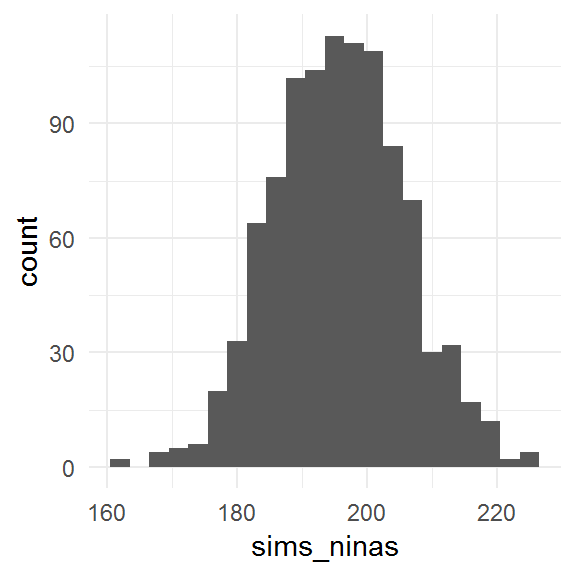

```r
ggplot() + geom_histogram(aes(x = sims_ninas), binwidth = 3)
```

El histograma de arriba representa la distribución de probabilidad aproximada para el número de niñas y toma en cuenta la incertidumbre.

[interactive chart not shown]

donde $p_1=48.8\%$ es la probabilidad de nacimientos de niñas únicos y $n_i, i=1,2,3$ son el número de nacimientos de niñas únicos, en gemelos fraternales y en gemélos idénticos, respectivamente.

Podemos simular 400 nacimientos bajo este modelo como sigue:

```r
set.seed(918739837)
tipo_nacimiento <- sample(c("unico", "fraternal", "identicos"),
  size = 400, replace = TRUE, prob = c(1 - 1 / 125 - 1 / 300, 1 / 125, 1 / 300))
n_unico <- sum(tipo_nacimiento == "unico")  # número de nacimientos únicos
n_fraternal <- sum(tipo_nacimiento == "fraternal")
n_identicos <- 400 - n_unico - n_fraternal
n_ninas <- rbinom(1, n_unico, 0.488) +
           rbinom(1, 2 * n_fraternal, 0.495) + # en cada nacimiento hay 2 bebés
           2 * rbinom(1, n_identicos, 0.405)
n_ninas
```

```
#> [1] 198
```

De nuevo, esto nos muestra una posible ocurrencia en 400 nacimientos. Ahora, para tener una noción de la distribución repetimos la simulación 1000 veces para aproximar la distribución de número de niñas en 400 nacimientos.

```r
modelo2 <- function(){
    tipo_nacimiento <- sample(c("unico", "fraternal", "identicos"),
        size = 400, replace = TRUE, prob = c(1 - 1 / 125 - 1 / 1300, 1 / 125, 1 / 300))
    # número de nacimientos de cada tipo
    n_unico <- sum(tipo_nacimiento == "unico")  # número de nacimientos únicos
    n_fraternal <- sum(tipo_nacimiento == "fraternal")
    n_identicos <- 400 - n_unico - n_fraternal
    # simulamos para cada tipo de nacimiento
    n_ninas <- rbinom(1, n_unico, 0.488) +
        rbinom(1, 2 * n_fraternal, 0.495) + # en cada nacimiento hay 2 bebés
    2 * rbinom(1, n_identicos, 0.495)
  n_ninas
}

sims_ninas_2 <- rerun(1000, modelo2()) %>% flatten_dbl()
mean(sims_ninas_2)
```

```
#> [1] 197
```

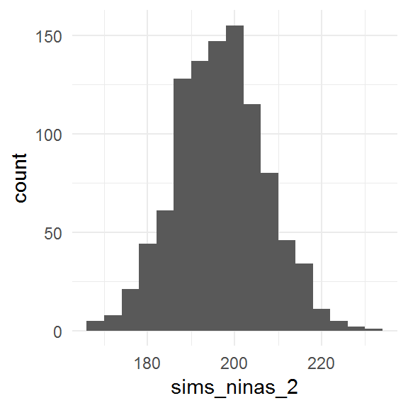

```r
ggplot() + geom_histogram(aes(x = sims_ninas_2), binwidth = 4)
```

### Simulación continua predictiva

El 52% de los adultos en EUA son mujeres y el 48% hombres. Las estaturas de los hombres se distribuyen aproximadamente normal con media 175 cm y desviación estándar de 7.37 cm; en el caso de las mujeres la distribución es aproximadamente normal con media 161.80 cm y desviación estándar de 6.86 cm. Supongamos que seleccionamos 10 adultos al azar. ¿qué podemos decir del promedio de estatura?

```r
set.seed(918739837)
sexo <- rbinom(10, 1, 0.52)
altura <- rnorm(sexo, mean = 161.8 * (sexo == 1) + 175 * (sexo == 0),
  sd = 6.86 * (sexo == 1) + 7.37 * (sexo == 0)) #Equivalente a simular de dos normales
mean(altura)
```

```
#> [1] 165
```

De nuevo, esto nos muestra una posible ocurrencia en una selección. Ahora, para tener una noción de la distribución de la altura promedio repetimos la simulación 1000 veces:

```r
mediaAltura <- function(){
  sexo <- rbinom(10, 1, 0.52)
  altura <- rnorm(sexo, mean = 161.8 * (sexo == 1) + 175 * (sexo == 0),
    sd = 6.86 * (sexo == 1) + 7.37 * (sexo == 0))
}
sims_alturas <- rerun(1000, mediaAltura())
media_alturas <- sims_alturas %>% map_dbl(mean)
mean(media_alturas)
```

```
#> [1] 168
```

```r
sd(media_alturas)
```

```
#> [1] 3.02
```

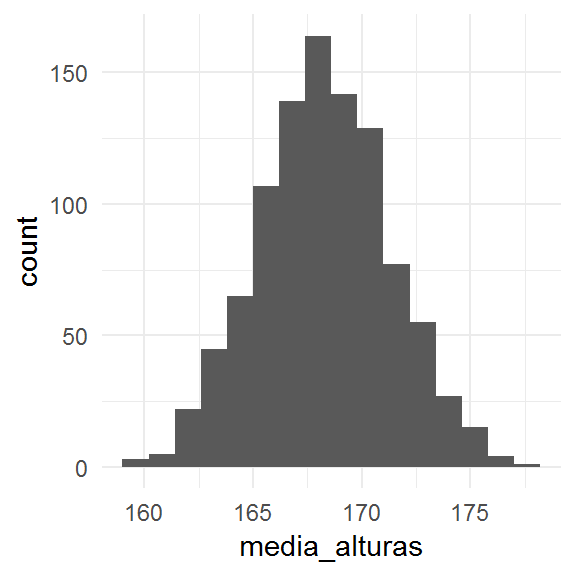

```r
ggplot() + geom_histogram(aes(x = media_alturas), binwidth = 1.2)
```

¿Y que podemos decir de la altura máxima?

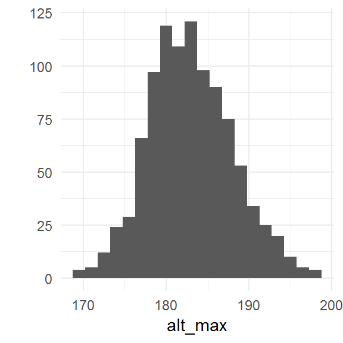

```r
alt_max <- sims_alturas %>% map_dbl(max)
qplot(alt_max, geom = "histogram", binwidth = 1.5)
```

**Ejercicio** Supongamos que una compañía cambia la tecnología usada para producir una cámara. Un estudio estima que el ahorro en la producción es de $5 por unidad con un error estándar de $4. Más aún, una proyección estima que el tamaño del mercado (esto es, el número de cámaras que se venderá) es de 40,000 con un error estándar de 10,000. Suponiendo que las dos fuentes de incertidumbre son independientes:

- Usa simulación para estimar el total de dinero que ahorrará la compañía.
- Calcula un intervalo de confianza.

### Simulación de un modelo de regresión

En regresión utilizamos simulación para capturar tanto la incertidumbre en la predicción (término de error en el modelo) como la incertidumbre en la inferencia (errores estándar de los coeficientes e incertidumbre del error residual).

Consideraremos un ejemplo en el que simulamos únicamente incertidumbre en la predicción.

**Ejemplo:** Supongamos que el puntaje de un niño de tres años en una prueba cognitiva esta relacionado con las características de la madre. El siguiente modelo resume la diferencia en los puntajes promedio de los niños cuyas madres se graduaron de preparatoria y los que no

$$y_i= \beta_0 + \beta_1 X_{i1} + \epsilon_i$$

donde $y$ es una variable aleatoria tal que $y_i$ representa el puntaje del i-ésimo niño, $X_{i1}$ es una variable binaria que indica si la madre se graduó de preparatoria (codificada como 1) o no (codificada como 0) y $\epsilon_i$ son los errores aleatorios; se asume que éstos son independientes con distribución normal $\epsilon_i \sim N(0, \sigma^2)$. Por tanto,

$$\mu_i \equiv E[y_i]= \beta_0 + \beta_1 X_{i1}$$

Asumimos que conocemos los coeficientes del modelo y que éstos están dados por:

$$\beta_0 = 78$$
$$\beta_1 = 12$$
$$\sigma = 20$$
El modelo gráfico asociado sería como sigue:

```r
grViz("
digraph regresion {
    graph [overlap = true]
    node [shape = box,penwidth = 0.1, fixedsize = true, fontsize = 9,
        fontname = Helvetica, width = 0.2, height = 0.2]
    beta_0[label = '&beta;&#x2080;']; beta_1[label = '&beta;&#x2081;']; mu_i[label='&mu;&#x2071;'];
    sigma[label = '&sigma;&#x00B2;']; X_i[label = 'X&#x2071;'];
    node [shape = circle,
        fixedsize = true, fontsize = 9,
        fontname = Helvetica, width = 0.2] // sets as circles
        Y_i[label = 'Y&#x2071;'];
    edge[color = grey, arrowsize = 0.5, penwidth = 0.5]
        mu_i->Y_i; sigma->Y_i;
    edge[color = grey, arrowsize = 0.5, penwidth = 1]
        beta_0->mu_i; beta_1 -> mu_i; X_i->mu_i;
}
")
```

[interactive chart not shown]

La pregunta que deseamos responder es: ¿cuál es la media esperada de los puntajes para un conjunto de 50 niños, 30 con madres que hicieron preparatoria y 20 que no?

Por tanto, consideremos el problema de simular el puntaje de 50 niños, 30 cuyas madres terminaron la preparatoria y 20 cuyas madres no terminaron.

Realizamos 2000 simulaciones de los 50 puntajes $y$:

```r
vector_mu <- c(rep(78 + 12, 30), rep(78, 20)) # beta_0 + beta_1 X
y <- rnorm(50, vector_mu, 20)
sims_y <- rerun(2000, rnorm(50, vector_mu, 20))
```

Podemos estimar la destribución de la media $\mu \equiv E[y]$ y algunos cuantiles:

```r
medias <- sims_y %>% map_dbl(mean)
quantile(medias, c(0.025, 0.975))
```

```
#>  2.5% 97.5%
#>  79.6  90.6
```

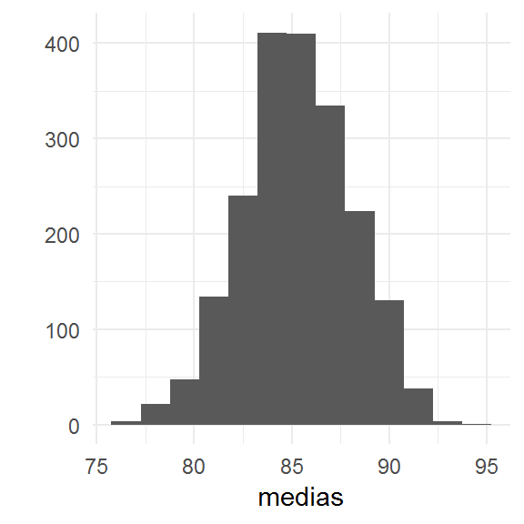

```r
qplot(medias, geom = "histogram", binwidth = 1.5)
```

Consideraremos ahora un ejemplo en el que en la simulación de incertidumbre en la predicción incorporamos incertidumbre en la inferencia.

**Ejemplo:** Considere el modelo de regresión del ejemplo anterior. Vamos a incorporar incertidumbre en la inferencia a través de incertidumbre en los coeficientes de regresión. Expresaremos esta incertidumbre asumiendo distribuciones de probabilidad de los coeficientes: ¿Cómo sería el modelo gráfico asociado?

Primero suponemos que $\sigma^2$ tiene una distribución centrada en $(20)^2$, inversamente proporcional a una distribución $\chi^2$ con 432 grados de libertad.

La manera de proceder para realizar una simulación es como sigue:

3. Simula el vector de observaciones $y$ usando los parámetros simulados en los pasos 1 y 2.

```r
set.seed(918739837)
# empezamos simulando sigma
sigma <- 20 * sqrt((432) / rchisq(1, 432))
sigma
```

```
#> [1] 20.6
```

```r
# la usamos para simular betas
beta <- MASS::mvrnorm(1, mu = c(78, 12), Sigma = sigma ^ 2 * matrix(c(0.011, -0.011, -0.011, 0.013), nrow = 2))
beta
```

```
#> [1] 80.4  9.6
```

```r
# simulamos los puntajes
vector_mu <- c(rep(beta[1] + beta[2], 30), rep(beta[1], 20)) # beta_0 + beta_1 X
vector_mu
```

```
#>  [1] 90.0 90.0 90.0 90.0 90.0 90.0 90.0 90.0 90.0 90.0 90.0 90.0 90.0 90.0
#> [15] 90.0 90.0 90.0 90.0 90.0 90.0 90.0 90.0 90.0 90.0 90.0 90.0 90.0 90.0
#> [29] 90.0 90.0 80.4 80.4 80.4 80.4 80.4 80.4 80.4 80.4 80.4 80.4 80.4 80.4
#> [43] 80.4 80.4 80.4 80.4 80.4 80.4 80.4 80.4
```

```r
obs = rnorm(50, vector_mu, sigma)
obs
```

```
#>  [1]  98.3  79.8  60.0 110.6 109.3  43.0  91.0  75.1  75.4 103.6  91.3
#> [12] 100.8  91.8  90.2 115.3  90.1 100.7 132.1  92.7  95.2  89.9  85.6
#> [23]  72.2 110.7  66.2  84.1  92.5 113.6  84.7  48.6  58.7  72.6 103.5
#> [34] 103.3  86.7  49.9  63.0  93.5  96.2  79.0  48.4  93.8  85.5  93.8
#> [45]  78.8 113.8  94.1  94.9  94.1  62.0
```

```r
#calculamos la media
mean(obs)
```

```
#> [1] 87.2
```

De nuevo, esto nos muestra una posible ocurrencia en una selección. Ahora, para tener una noción de la distribución de la media de los puntajes repetimos la simulación 2000 veces:

```r
simula_parametros <- function(){
    # empezamos simulando sigma
    sigma <- 20 * sqrt((432) / rchisq(1, 432))
    # la usamos para simular betas
    beta <- MASS::mvrnorm(1, mu = c(78, 12),
        # Sigma = sigma ^ 2 * matrix(c(4.2, -4.2, -4.2, 5.4), nrow = 2))
        Sigma = sigma ^ 2 * matrix(c(0.011, -0.011, -0.011, 0.013), nrow = 2))
    # Simulamos las observaciones
    list(sigma = sigma, beta = beta)
}

sims_parametros <- rerun(2000, simula_parametros())

# simulamos los puntajes
simula_puntajes <- function(beta, sigma, n_hs = 30, n_nhs = 20){
    vector_mu <- c(rep(beta[1] + beta[2], n_hs), rep(beta[1], n_nhs)) # beta_0 + beta_1 X
    obs = rnorm(50, vector_mu, sigma)
}

sims_puntajes <- map(sims_parametros, ~simula_puntajes(beta = .[["beta"]], sigma = .[["sigma"]]))
sims_medias <- sims_puntajes %>% map_dbl(mean)

# Calculamos algunos cuantiles
quantile(sims_medias, c(0.025, 0.975))
```

```
#>  2.5% 97.5%
#>  79.5  91.2
```

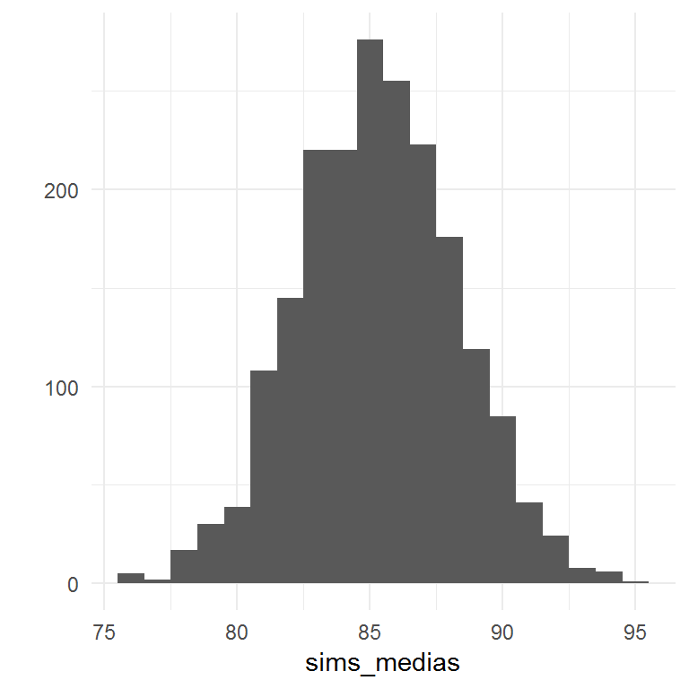

```r
# Graficamos la distribución de las medias
qplot(sims_medias, geom = "histogram", binwidth = 1)
```

También podemos usar la simulación para calcular incertidumbre en la estimación de $\beta_0$ y $\beta_1$,

```r
sims_parametros %>% map_dbl(~(.$beta[1])) %>% sd()
```

```
#> [1] 2.05
```

```r
sims_parametros %>% map_dbl(~(.$beta[2])) %>% sd()
```

```
#> [1] 2.23
```

En este ejemplo, es posible calcular incertidumbre en las estimaciones de los coeficientes de manera analíticamente; sin embargo, en otras situaciones esto no es posible.

Con simulación podemos responder fácilmente ésta y otras otras preguntas; por ejemplo, la pregunta inicial: ¿cuál es la media esperada de los puntajes para un conjunto de 50 niños, 30 con madres que hicieron preparatoria y 20 que no?

#### Referencias

- Andrew Gelman, Jennifer Hill (2007) [Data Analysis Using Regression and Multilevel/Hierarchical Models](http://www.stat.columbia.edu/~gelman/arm/).